# Diversity effects: the enemies hypothesis

collnell

July 5, 2016

```r
std <- function(x) sd(x)/sqrt(length(x))

##clean data
drops<-c("Grand.Total","X.blank.")##clean up df
birds=birds[,!(names(birds) %in% drops)]
birds[is.na(birds)]<-0
cols<-names(birds)
drops<-c("DIVERSITY","PLOT","VISIT")
sps<-cols[-c(1:3)]##this is a list of the names of the birds only
birds$VISIT<-as.character(birds$VISIT)
birds$total_abun<-rowSums(birds[,sps])
bird.sp<-birds[,sps]#matrix plot x sp
bird.poly<-birds%>%
  filter(DIVERSITY == 'P')
bird.poly.mat<-bird.poly[,sps]
bird.mono<-birds%>%
  filter(DIVERSITY == 'M')
bird.mono.mat<-bird.mono[,sps]

##summarize data for plots/analyses
#by plot
#abundance
bird.visit<-birds%>%
  mutate(birds_visit=rowSums(.[sps]))
bird.visit$VISIT<-as.character(bird.visit$VISIT)
bird.visit$PLOT<-as.character(bird.visit$PLOT)
bird.plot<-birds%>%
  mutate(birds_plot_visit=rowSums(.[sps]))%>%
  group_by(DIVERSITY,PLOT)%>%
  summarize(total_birds_plot=sum(birds_plot_visit),
            n_visit=length(VISIT),
            mean_birds_visit=mean(birds_plot_visit),
            se_birds_visit=std(birds_plot_visit))

bird.div<-bird.plot%>%
  group_by(DIVERSITY)%>%
  summarize(total_birds_div=sum(total_birds_plot),
            n_plots=length(PLOT),
            mean_birds_plot_visit=mean(mean_birds_visit),
            se_birds_plot_visit=std(mean_birds_visit))

birds.melt<-melt(birds,id.vars=c("DIVERSITY","PLOT","VISIT","total_abun"),variable.name="ID")%>%
  left_join(sp.list[,c("ID","feeding.guild","Family","Order")],by="ID")
insect.birds<-birds.melt%>%
  filter(feeding.guild %in% c("IN","FL","OM"))

ins.plot<-insect.birds%>%
  group_by(DIVERSITY,PLOT,VISIT)%>%
  summarize(total_birds_plot_visit=sum(value))%>%
  group_by(DIVERSITY,PLOT)%>%
  summarize(total_birds_plot = sum(total_birds_plot_visit),
            mean_birds_visit = mean(total_birds_plot_visit),
            n_visit=as.numeric(max(VISIT)),
            se_birds_visit = std(total_birds_plot_visit))
```

# Bird Observations

### All Birds

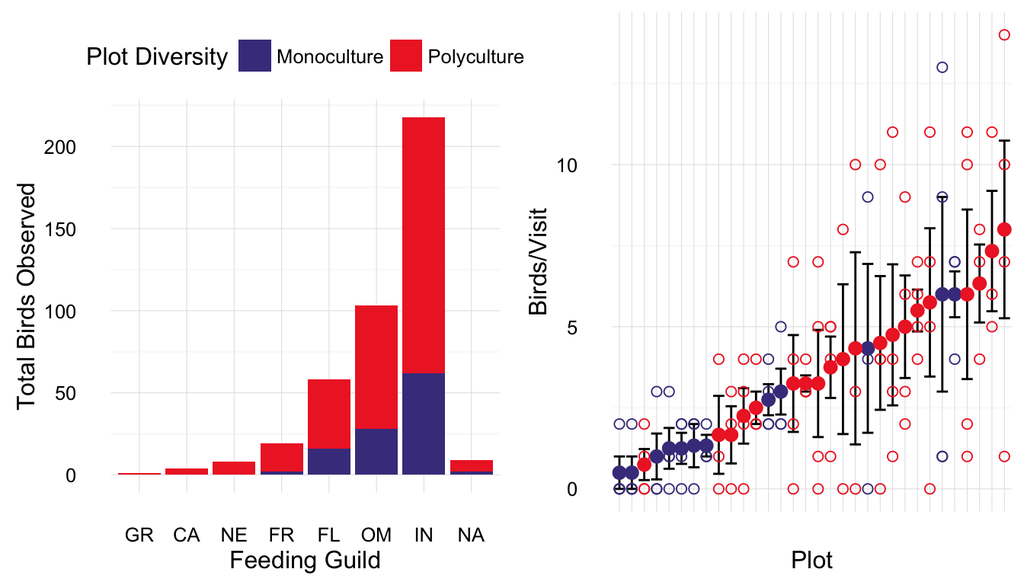

```r
div.guild<-birds.melt%>%###this is the total number of birds~diversity+feeding guild
  group_by(DIVERSITY,feeding.guild)%>%
  summarize(total_birds = sum(value))

plot.visit<-birds.melt%>%
  group_by(DIVERSITY,PLOT,VISIT)%>%
  summarize(total_birds_plot=sum(value))%>%
  group_by(DIVERSITY,PLOT)%>%
  summarize(mean_birds_plot = mean(total_birds_plot))

plot.guild<-birds.melt%>%
  group_by(DIVERSITY,PLOT,VISIT,feeding.guild)%>%
  summarize(total_birds_visit = sum(value))%>%
  group_by(DIVERSITY,PLOT,feeding.guild)%>%
  summarize(mean_birds_visit=mean(total_birds_visit),se_birds_visit = std(total_birds_visit))%>%
  left_join(plot.visit[,c("PLOT","mean_birds_plot")],by="PLOT")%>%
  mutate(per_birds_visit= (mean_birds_visit/mean_birds_plot)*100)

plot.dcast<-dcast(plot.guild,DIVERSITY+PLOT~feeding.guild)##div + plot ~guilds in percentages


guilddiv<-ggplot(div.guild,aes(y=total_birds,x=reorder(feeding.guild,total_birds),fill=DIVERSITY))+
  geom_bar(stat="identity")+
  scale_fill_manual("Plot Diversity",labels=c("Monoculture","Polyculture"),values=c("darkslateblue","firebrick2"))+
  theme_minimal()+theme(legend.position="top")+labs(x="Feeding Guild",y="Total Birds Observed")

abun_by_plot<-ggplot(bird.plot,aes(x=reorder(PLOT,mean_birds_visit),y=mean_birds_visit,color=DIVERSITY))+
  geom_errorbar(aes(ymin=mean_birds_visit-se_birds_visit,ymax=mean_birds_visit+se_birds_visit),color="black")+
  geom_point(size=3,shape=16)+
  scale_color_manual("Plot Diversity",labels=c("Monoculture","Polyculture"),values=c("darkslateblue","firebrick2"))+
  theme_minimal()+
  theme(legend.position="none",axis.text.x=element_blank())+
  labs(x="Plot",y="Birds/Visit")
allabun<-abun_by_plot+geom_point(data=bird.visit,aes(x=reorder(PLOT,total_abun),y=total_abun),size=2,shape=1)

plot_grid(guilddiv,allabun)
```

```r
rarc.poly<-rarc(bird.poly.mat,nrandom=99)
```

```
FALSE done
```

```r
rarc.mono<-rarc(bird.mono.mat,nrandom=99)
```

```
FALSE done
```

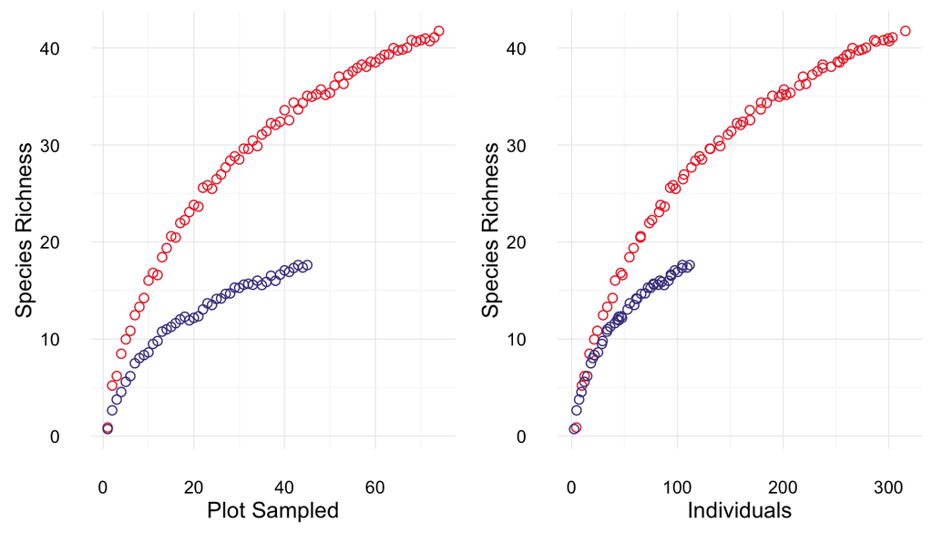

```r
div.rarc<-ggplot()+#by samples
  geom_point(data=rarc.poly,aes(x=samples,y=richness),size=2,shape=1,color="firebrick2")+
  geom_point(data=rarc.mono,aes(x=samples,y=richness),size=2,shape=1,color="darkslateblue")+
  theme_minimal()+labs(x="Plot Sampled",y="Species Richness")

div.rarc.ind<-ggplot()+#by individuals
  geom_point(data=rarc.poly,aes(x=individuals,y=richness),size=2,shape=1,color="firebrick2")+
  geom_point(data=rarc.mono,aes(x=individuals,y=richness),size=2,shape=1,color="darkslateblue")+
  theme_minimal()+labs(x="Individuals",y="Species Richness")

plot_grid(div.rarc,div.rarc.ind)
```

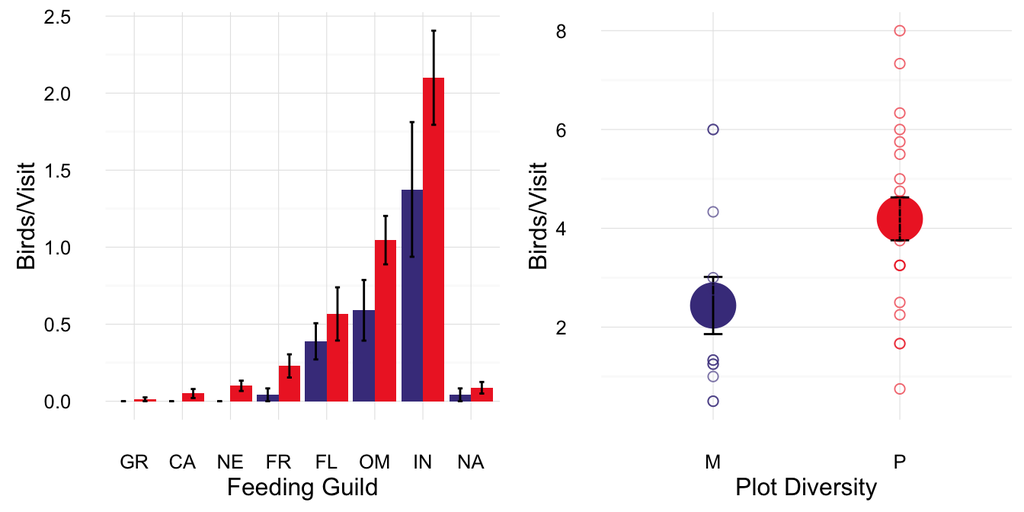

```r
plot.guild2<-birds.melt%>%
  group_by(DIVERSITY,PLOT,VISIT,feeding.guild)%>%
  summarize(total_birds_visit = sum(value))
plot.guild3<-plot.guild2%>%
  group_by(DIVERSITY,PLOT,feeding.guild)%>%
  summarize(mean_birds_visit=mean(total_birds_visit),se_birds_visit = std(total_birds_visit))%>%
  group_by(DIVERSITY,feeding.guild)%>%
  summarize(mean_birds_div = mean(mean_birds_visit), se_birds_div = std(mean_birds_visit))

divguild.plot<-ggplot(plot.guild3,aes(x=reorder(feeding.guild,mean_birds_div),y=mean_birds_div,fill=DIVERSITY))+
  geom_bar(stat="identity",position="dodge")+theme_minimal()+scale_fill_manual(values=c("darkslateblue","firebrick2"))+
  geom_errorbar(aes(ymin=mean_birds_div-se_birds_div,ymax=mean_birds_div+se_birds_div),width=.2,position=position_dodge(.9))+theme(legend.position="none")+
  labs(x="Feeding Guild",y="Birds/Visit")


div_abun_plot<-ggplot(bird.div,aes(x=DIVERSITY,y=mean_birds_plot_visit,color=DIVERSITY))+
  geom_point(size=10,shape=19)+
  geom_errorbar(aes(ymin=mean_birds_plot_visit-se_birds_plot_visit,ymax=mean_birds_plot_visit+se_birds_plot_visit),color="black",width=.1)+
  labs(x="Plot Diversity",y="Birds/Visit")+
  theme_minimal()+
  scale_color_manual(labels=c("Monoculture","Polyculture"),values=c("darkslateblue","firebrick2"))+theme(legend.position="none")
div_abun_plos<-div_abun_plot+geom_point(data=bird.plot,aes(x=DIVERSITY,y=mean_birds_visit),size=2,shape=1,alpha=.65)

plot_grid(divguild.plot,div_abun_plos)
```

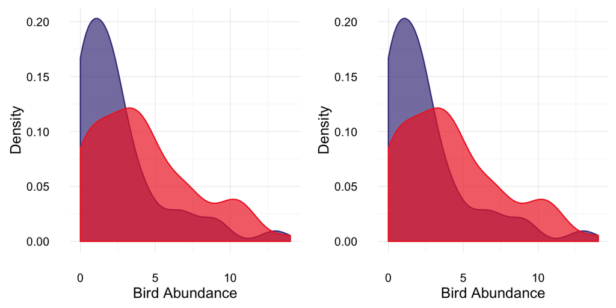

```r
hist.div<-ggplot(bird.visit,aes(x=total_abun,fill=DIVERSITY,color=DIVERSITY),alpha=.6)+geom_density(alpha=.7)+
  theme_minimal()+labs(y="Density",x="Bird Abundance")+
  scale_fill_manual("Plot Diversity",labels=c("Monoculture","Polyculture"),values=c("darkslateblue","firebrick2"))+scale_color_manual("Plot Diversity",labels=c("Monoculture","Polyculture"),values=c("darkslateblue","firebrick2"))+
  theme(legend.position="none")
plot_grid(hist.div,hist.div)
```

```r
abun.by.div<-aov(birds_visit~DIVERSITY+Error(PLOT),data=bird.visit)
pander(summary(abun.by.div),round=c(0,2,2,3,3))
```

|  | Df | Sum Sq | Mean Sq | F value | Pr(>F) |
| --- | --- | --- | --- | --- | --- |
| **DIVERSITY** | 1 | 85.18 | 85.18 | 5.945 | 0.021 |
| **Residuals** | 30 | 429.9 | 14.33 | NA | NA |
| **Residuals1** | 87 | 776.6 | 8.93 | NA | NA |

testing for main effects of tree diversity with plot as random effect.

```r
rtr<-lm(total_birds_visit~DIVERSITY*feeding.guild+PLOT,data=plot.guild2)
pander(summary(aov(rtr)),round=c(0,2,2,3,3))
```

Analysis of Variance Model testing for main and interactive effects of tree diversity and feeding guild on bird abundance.

|  | Df | Sum Sq | Mean Sq | F value | Pr(>F) |
| --- | --- | --- | --- | --- | --- |
| **DIVERSITY** | 1 | 11.48 | 11.48 | 10.34 | 0.001 |
| **feeding.guild** | 6 | 317.7 | 52.95 | 47.68 | 0 |
| **PLOT** | 1 | 0.17 | 0.17 | 0.149 | 0.7 |
| **DIVERSITY:feeding.guild** | 6 | 10.36 | 1.73 | 1.555 | 0.157 |
| **Residuals** | 818 | 908.5 | 1.11 | NA | NA |

Guilds: Granivorous (GR), Carnivorous (CA), Nectivorous (NE), Frugivorous (FR), Insectivorous (FL = flycatching, IN= gleaning), Omnivorous (OM), NA = unidentified

### Richness

All Birds

```r
allrichness<-rich(matrix=bird.sp,verbose=T)
```

```
## computing...
```

Mean richness plot/visit: 2.1512605  
Total richness: 55  
Singletons: 15

### Insectivorous Birds

(including gleaners, flycatchers, and omnivores that consume arthropods)

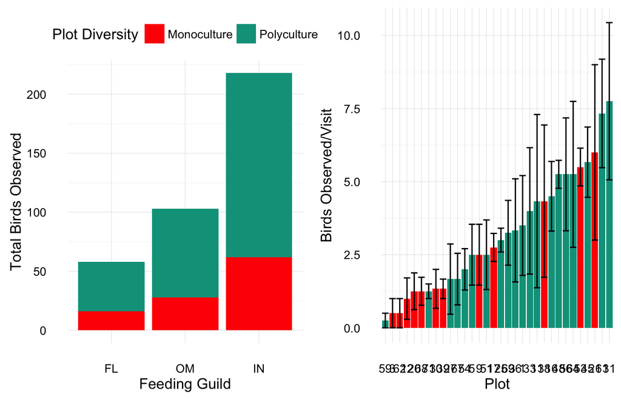

```r
ins.guild<-insect.birds%>%###this is the total number of insecitvorous birds~diversity+feeding guild
  group_by(DIVERSITY,feeding.guild)%>%
  summarize(total_birds = sum(value))

guilddiv<-ggplot(ins.guild,aes(y=total_birds,x=reorder(feeding.guild,total_birds),fill=DIVERSITY))+
  geom_bar(stat="identity")+
  scale_fill_manual("Plot Diversity",labels=c("Monoculture","Polyculture"),values=wes_palette("Darjeeling"))+
  theme_minimal()+theme(legend.position="top")+labs(x="Feeding Guild",y="Total Birds Observed")

abun_by_plot<-ggplot(ins.plot,aes(x=reorder(PLOT,mean_birds_visit),y=mean_birds_visit,fill=DIVERSITY))+
  geom_bar(stat="identity")+
  geom_errorbar(aes(ymin=mean_birds_visit-se_birds_visit,ymax=mean_birds_visit+se_birds_visit))+
  scale_fill_manual("Plot Diversity",labels=c("Monoculture","Polyculture"),values=wes_palette("Darjeeling"))+
  theme_minimal()+
  theme(legend.position="none")+
  labs(x="Plot",y="Birds Observed/Visit")

plot_grid(guilddiv,abun_by_plot)
```

**379 observations** of **40 species** from **17 families** (Caprimulgidae, Cardinalidae, Corvidae, Cracidae, Cuculidae, Icteridae, Mimidae, Momotidae, Parulidae, Picidae, Polioptilidae, Thraupidae, Troglodytidae, Turdidae, Tyrannidae, Tytiridae, Vireonidae) and **7 orders**(, Caprimulgiformes, Coraciiformes, Cuculiformes, Galliformes, Passeriformes, Piciformes)

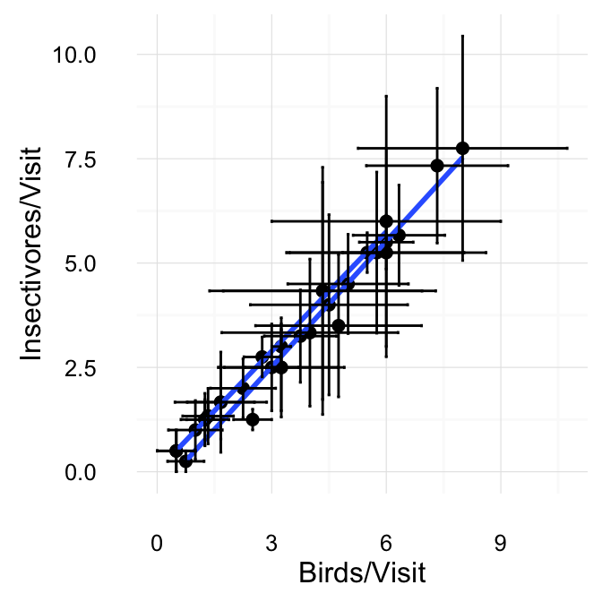

```r
compareins<-left_join(bird.plot,ins.plot,by="PLOT")
ins.by.total<-lm(mean_birds_visit.x~mean_birds_visit.y,data=compareins)
p<-summary(ins.by.total)$coefficients[,4]
r2<-summary(ins.by.total)$r.squared

typeplot<-ggplot(compareins,aes(x=mean_birds_visit.x,y=mean_birds_visit.y,fill=DIVERSITY.x))+
  geom_point(size=2)+geom_smooth(method="lm",se=F)+
  geom_errorbar(aes(ymin=mean_birds_visit.y-se_birds_visit.y,ymax=mean_birds_visit.y+se_birds_visit.y))+
  geom_errorbarh(aes(xmin=mean_birds_visit.x-se_birds_visit.x,xmax=mean_birds_visit.x+se_birds_visit.x))+
  theme_minimal()+
  scale_fill_manual(values=wes_palette("Darjeeling"))+
  theme(legend.position="none")+
  labs(x="Birds/Visit",y="Insectivores/Visit")
typeplot
```

```r
summary(ins.by.total)
```

```
##
## Call:
## lm(formula = mean_birds_visit.x ~ mean_birds_visit.y, data = compareins)
##
## Residuals:
##     Min      1Q  Median      3Q     Max
## -0.4220 -0.2894 -0.1011  0.1972  0.9624
##
## Coefficients:
##                    Estimate Std. Error t value Pr(>|t|)
## (Intercept)          0.2599     0.1236   2.103    0.044 *
## mean_birds_visit.y   1.0221     0.0327  31.253   <2e-16 ***
## ---
## Signif. codes:  0 '***' 0.001 '**' 0.01 '*' 0.05 '.' 0.1 ' ' 1
##
## Residual standard error: 0.3714 on 30 degrees of freedom
## Multiple R-squared:  0.9702, Adjusted R-squared:  0.9692
## F-statistic: 976.8 on 1 and 30 DF,  p-value: < 2.2e-16
```

### Exploratory Analysis

The following figures look at characteristics of the bird observation data, and the relationships between species abundance, occurance, and sampling effort.

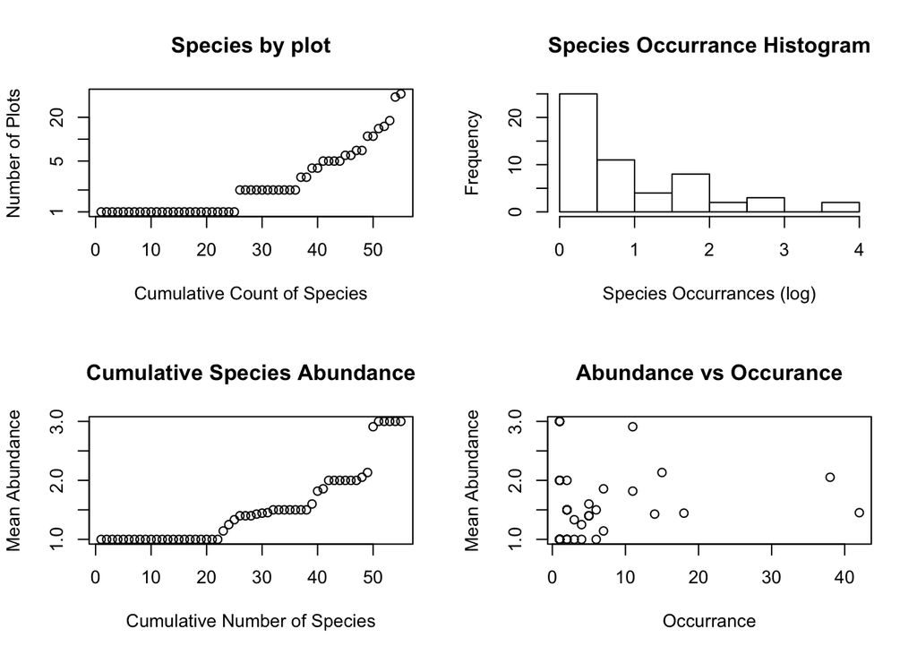

```r
spc_pres<-apply(bird.sp>0,2,sum)
par(mfrow=c(2,2))
occur<-plot(sort(spc_pres),log='y',main="Species by plot",xlab='Cumulative Count of Species',ylab='Number of Plots')#cumulative plot of species(x) by plot(y)
##cumulative distribution of species occuranes
histo<-hist(log(spc_pres),10,main="Species Occurrance Histogram",xlab="Species Occurrances (log)")#histogram

tmp<-apply(bird.sp,2,sum)
spc_mean<-tmp/spc_pres #avg cover for each species
cumsp<-plot(sort(spc_mean),main="Cumulative Species Abundance",
     xlab="Cumulative Number of Species", ylab="Mean Abundance")

##is  mean abun of sp correlated with # of plots occur in?
abunplotcorr<-plot(spc_pres,spc_mean,main="Abundance vs Occurance",xlab="Occurrance",ylab="Mean Abundance")
```

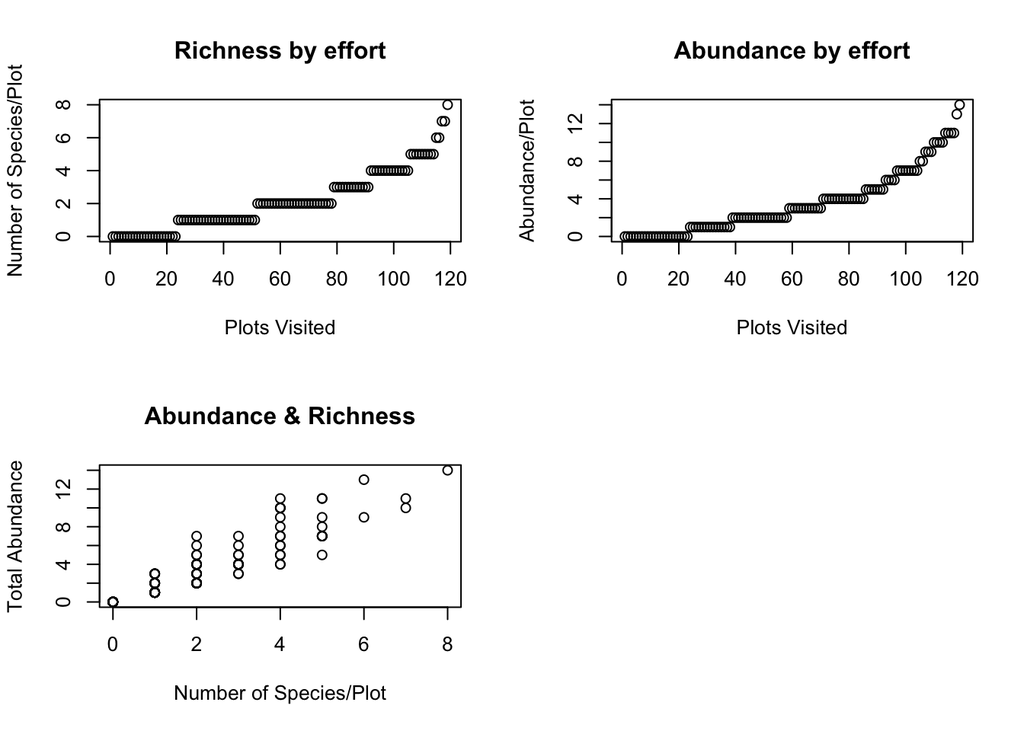

```r
#yes

#is total abundance correlated with number of species?
plt_pres<-apply(bird.sp>0,1,sum)
abuncorsp<-plot(sort(plt_pres),main="Richness by effort",xlab="Plots Visited",ylab="Number of Species/Plot")
#yes

##total abun on each plot
plt_sum<-apply(bird.sp,1,sum)##calculate total abundance for each plot
abunbyrich<-plot(sort(plt_sum),main="Abundance by effort",xlab="Plots Visited",ylab="Abundance/Plot")

##relationship between number of species/plot and total abundance
spabund<-plot(plt_pres,plt_sum,main="Abundance & Richness",xlab="Number of Species/Plot",ylab="Total Abundance")##number of species/plot, total abundance
```

# Data

### Description

These data are from a field experiment conducted July 2015 at the [UADY forest diversity plots near Muna, Yucatan, Mexico](http://www.treedivnet.ugent.be/ExpUADY.html). Using the tree diversity manipulation we test the predictions that  
(1) tree diversity promotes the abundance and diversity of predators (insectivorous birds) and  
(2) via effects on predators, tree diversity is correlated with greater herbivore suppression.

### Data sheets

[**Bird List**](https://github.com/collnell/Enemies/blob/master/enemy_bird_list.csv)  
Inventory on all bird species recorded at the UADY diversity plots in January and July of 2015. Contians species codes and associated information for each ID (including feeding guild).

**Predation Experiment**  
These data are from a clay caterpillar experiment used to assay predation rates between the plots. For each experimental plot, 2 clay models were placed on opposite branches of 12 trees. Models were visited twice, 24 and 48 hours after placement, to record attack marks. Marked models were identified as either Arthropod, Bird, and Mammal and replced with a new model.

**Experimental Design**  
Data on plots used in experiment. Plot diversity, tree species, ETC